# Piloting Graph Learning in Adults

```r
suppressMessages(library(summarytools, quietly = TRUE))
suppressMessages(library(dplyr, quietly = TRUE))
logdir='~/Dropbox/projects/in_progress/network_learning/code/netlearn_kids_v1/logs/'
datadir='~/Dropbox/projects/in_progress/network_learning/code/netlearn_kids_v1/subjData/'
```

We started out running adults with exposure walks of ~200-300 trials, but in service of having it be doable for kids, iterated down to 150 trials. Here we examine only data from adults run on a version of the task with 150 trials of exposure (NL004 and onwards). Each subject has either the OMOT or the Dyadic Choice task.

At NL008, made the change for tapping on the monsters to advance, tap as quickly as you can, the tap makes a sound, and string all assessments together rather than opening each separately.

## NL004

```r
exposureData <- read.delim(paste0(logdir, "NL004/NL004_log_run1.csv"))
seqcmplData <- read.csv(paste0(datadir, "NL004/seqcmpl/NL004_log_seqcmpl.csv"))
#omotData<- read.csv(paste0(datadir, "NL004/OMOT/NL004_log_omot.csv"))
dyadData <- read.csv(paste0(datadir, "NL004/dyad_choice/NL004_log_dyad_choice.csv"))
seqcmplData$correct <- factor(seqcmplData$correct, ordered=TRUE, levels=c(0,1), labels=c("Incorrect", "Correct"))
#omotData$correct <- factor(omotData$correct, ordered=TRUE, labels=c("Incorrect", "Correct")) #commented out because if make them factors then can't do proportion calculations on them.
```

### Exposure data

What does reaction time on the exposure walk look like?

```r
view(dfSummary(exposureData))
```

```
## Method 'viewer' only valid within RStudio. Switching method to 'browser'.
```

```
## Output file written: /var/folders/m4/l8x9203x15n77thcpm1t4x8m0000gq/T//RtmpGkaQ0L/filee74f3b0f762a.html
```

```r
summary(exposureData$rt)
```

```
##    Min. 1st Qu.  Median    Mean 3rd Qu.    Max.
## 0.01926 0.73340 1.25557 1.84206 2.41541 9.59500
```

**Does RT go down or up as the task goes on?**

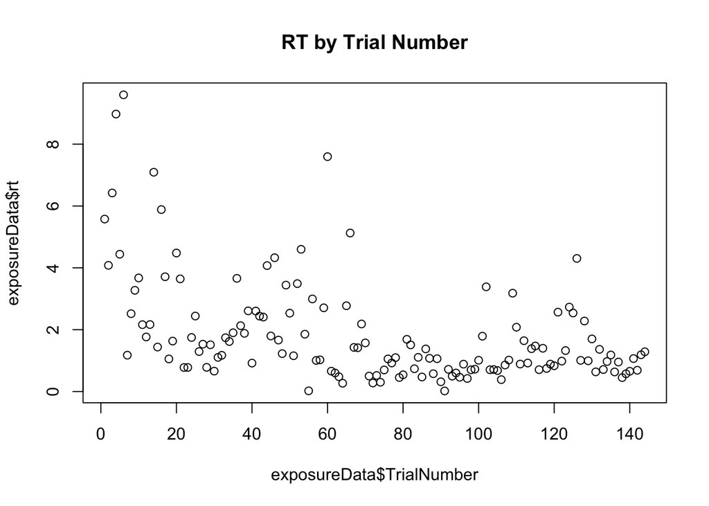

```r
plot(exposureData$TrialNumber, exposureData$rt, main= "RT by Trial Number")
```

```r
cor.test(exposureData$TrialNumber, exposureData$rt)
```

```
##
##  Pearson's product-moment correlation
##
## data:  exposureData$TrialNumber and exposureData$rt
## t = -6.2957, df = 142, p-value = 3.585e-09
## alternative hypothesis: true correlation is not equal to 0
## 95 percent confidence interval:
##  -0.5859396 -0.3286756
## sample estimates:
##        cor
## -0.4671367
```

It goes down (not surprisingly)!

**Is RT longer after transition nodes?**

```r
exposureData$transition_node <- ifelse((exposureData$node1==4 & exposureData$node2 ==5) |(exposureData$node1 ==5 & exposureData$node2 ==4), 1, 0)
exposureData$transition_node <- factor(exposureData$transition_node, labels=c("No", "Yes"))
exposureData %>%  group_by(transition_node) %>% summarise(avg_rt=mean(rt), med_rt=median(rt), std_dev=sd(rt), n_trials=n())
```

| transition_node | avg_rt | med_rt | std_dev | n_trials |
| --- | --- | --- | --- | --- |
| No | 1.864656 | 1.292920 | 1.7008249 | 139 |
| Yes | 1.213932 | 0.983389 | 0.7989158 | 5 |

No, it’s not.

**How long does it take with 150 nodes?**

```r
max(exposureData$onset)/60
```

```
## [1] 9.401333
```

### Sequence Completion Task

```r
table(seqcmplData$correct)
```

```
##
## Incorrect   Correct
##         0         8
```

How many are correct (within rather than between community)? 100%

### Dyadic Choice

```r
mean(dyadData$correct)
```

```
## [1] 0.7692308
```

77% correct on Dyadic Choice.

Does average number correct differ by trial type?

```r
dyadData %>% group_by(trial_type) %>% summarise(avg_correct=mean(correct))
```

| trial_type | avg_correct |
| --- | --- |
| friends_between | 1.000 |
| friends_within | 1.000 |
| non_friends_between_dist2 | 0.250 |
| non_friends_between_dist4 | 0.500 |
| non_friends_within | 0.875 |

Does the average number they say are friends (yes answers) differ by trial type?

Haven’t done this here.

**Does RT differ by trial type?**

```r
dyadData %>% group_by(trial_type) %>% summarise(avg_rt=mean(rt), med_rt=median(rt), std_dev=sd(rt), n_trials=n())
```

| trial_type | avg_rt | med_rt | std_dev | n_trials |
| --- | --- | --- | --- | --- |
| friends_between | 1.539195 | 1.539195 | 0.2553999 | 2 |
| friends_within | 1.480892 | 1.486080 | 0.2919737 | 8 |
| non_friends_between_dist2 | 2.958042 | 2.541690 | 1.6713878 | 4 |
| non_friends_between_dist4 | 1.736657 | 1.888150 | 0.4834985 | 4 |
| non_friends_within | 3.702998 | 2.060315 | 3.7354185 | 8 |

Yes! RT is longer in friends-between trials than friends-within, as expected. RT is longest in what should be the hardest trials (non-friends between distance 2 and non-friends within)

**Does RT differ by sequence-longer later in the sequence, or shorter?**

```r
cor.test(dyadData$TrialNumber, dyadData$rt)
```

```
##
##  Pearson's product-moment correlation
##
## data:  dyadData$TrialNumber and dyadData$rt
## t = -2.2396, df = 24, p-value = 0.03465
## alternative hypothesis: true correlation is not equal to 0
## 95 percent confidence interval:
##  -0.69171765 -0.03386735
## sample estimates:
##       cor
## -0.415765
```

No, RT goes down with more trials.

## NL005

```r
exposureData <- read.delim(paste0(logdir, "NL005/NL005_log_run1.csv"))
seqcmplData <- read.csv(paste0(datadir, "NL005/seqcmpl/NL005_log_seqcmpl.csv"))
omotData<- read.csv(paste0(datadir, "NL005/OMOT/NL005_log_omot.csv"))
#dyadData <- read.csv(paste0(datadir, "NL004/dyad_choice/NL004_log_dyad_choice.csv"))
seqcmplData$correct <- factor(seqcmplData$correct, ordered=TRUE, levels=c(0,1), labels=c("Incorrect", "Correct"))
#omotData$correct <- factor(omotData$correct, ordered=TRUE, labels=c("Incorrect", "Correct")) #commented out because if make them factors then can't do proportion calculations on them.
```

### Exposure data

What does reaction time on the exposure walk look like?

```r
summary(exposureData$rt)
```

```
##     Min.  1st Qu.   Median     Mean  3rd Qu.     Max.
##  0.02046  1.10687  2.59379  3.15493  4.66751 10.46850
```

**Does RT go down or up as the task goes on?**

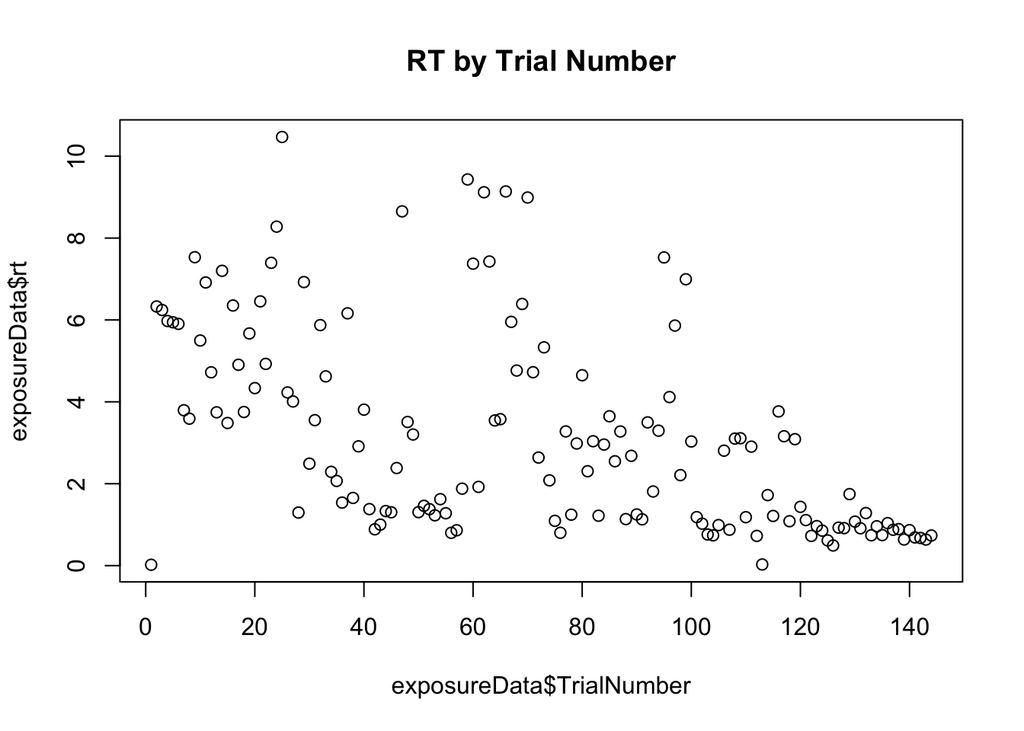

```r
plot(exposureData$TrialNumber, exposureData$rt, main= "RT by Trial Number")
```

```r
cor.test(exposureData$TrialNumber, exposureData$rt)
```

```
##
##  Pearson's product-moment correlation
##
## data:  exposureData$TrialNumber and exposureData$rt
## t = -7.5738, df = 142, p-value = 4.228e-12
## alternative hypothesis: true correlation is not equal to 0
## 95 percent confidence interval:
##  -0.6435173 -0.4086892
## sample estimates:
##        cor
## -0.5364055
```

It goes down (not surprisingly)!

**Is RT longer after transition nodes?**

```r
exposureData$transition_node <- ifelse((exposureData$node1==4 & exposureData$node2 ==5) |(exposureData$node1 ==5 & exposureData$node2 ==4), 1, 0)
exposureData$transition_node <- factor(exposureData$transition_node, labels=c("No", "Yes"))
exposureData %>%  group_by(transition_node) %>% summarise(avg_rt=mean(rt), med_rt=median(rt), std_dev=sd(rt), n_trials=n())
```

| transition_node | avg_rt | med_rt | std_dev | n_trials |
| --- | --- | --- | --- | --- |
| No | 3.025309 | 2.38290 | 2.360587 | 139 |
| Yes | 6.758488 | 7.52706 | 1.957610 | 5 |

Yes, by a lot!

**How long does it take with 150 nodes?**

```r
max(exposureData$onset)/60
```

```
## [1] 12.57992
```

### Sequence Completion Task

```r
table(seqcmplData$correct)
```

```
##
## Incorrect   Correct
##         0         8
```

How many are correct (within rather than between community)? 100%

### Odd Man Out Task

```r
summary(omotData$correct)
```

```
##    Min. 1st Qu.  Median    Mean 3rd Qu.    Max.
##  0.0000  1.0000  1.0000  0.7708  1.0000  1.0000
```

Does average number correct differ by trial type?

```r
omotData %>% group_by(trial_type) %>% summarise(avg_correct=mean(correct))
```

| trial_type | avg_correct |
| --- | --- |
| catch | 0.5000000 |
| conservative | 1.0000000 |
| non_conservative | 0.7222222 |

The ‘correct’ answer for catch trials is the node that is 2 edges away rather than one edge away. 72% is still above chance on the non-conservative trials!

**Does RT differ by trial type?**

```r
omotData %>% group_by(trial_type) %>% summarise(avg_rt=mean(rt), med_rt=median(rt), std_dev=sd(rt), n_trials=n())
```

| trial_type | avg_rt | med_rt | std_dev | n_trials |
| --- | --- | --- | --- | --- |
| catch | 4.535922 | 3.844845 | 2.8054468 | 12 |
| conservative | 2.347628 | 2.193610 | 0.7968343 | 18 |
| non_conservative | 4.691241 | 3.277810 | 3.1683016 | 18 |

Average RT is lowest in conservative trials, as we would expect, since these should be the easiest!

**Does RT differ by sequence-longer later in the sequence, or shorter?**

```r
cor.test(omotData$TrialNumber, omotData$rt)
```

```
##
##  Pearson's product-moment correlation
##
## data:  omotData$TrialNumber and omotData$rt
## t = -1.3014, df = 46, p-value = 0.1996
## alternative hypothesis: true correlation is not equal to 0
## 95 percent confidence interval:
##  -0.4485588  0.1011071
## sample estimates:
##        cor
## -0.1884411
```

Not significantly.

## NL006

```r
exposureData <- read.delim(paste0(logdir, "NL006/NL006_log_run1.csv"))
seqcmplData <- read.csv(paste0(datadir, "NL006/seqcmpl/NL006_log_seqcmpl.csv"))
#omotData<- read.csv(paste0(datadir, "NL006/OMOT/NL006_log_omot.csv"))
dyadData <- read.csv(paste0(datadir, "NL006/dyad_choice/NL006_log_dyad_choice.csv"))
seqcmplData$correct <- factor(seqcmplData$correct, ordered=TRUE, levels=c(0,1), labels=c("Incorrect", "Correct"))
#omotData$correct <- factor(omotData$correct, ordered=TRUE, labels=c("Incorrect", "Correct")) #commented out because if make them factors then can't do proportion calculations on them.
```

### Exposure data

What does reaction time on the exposure walk look like?

```r
summary(exposureData$rt)
```

```
##    Min. 1st Qu.  Median    Mean 3rd Qu.    Max.
## 0.01529 0.86403 1.28178 1.83552 2.48924 7.79787
```

**Does RT go down or up as the task goes on?**

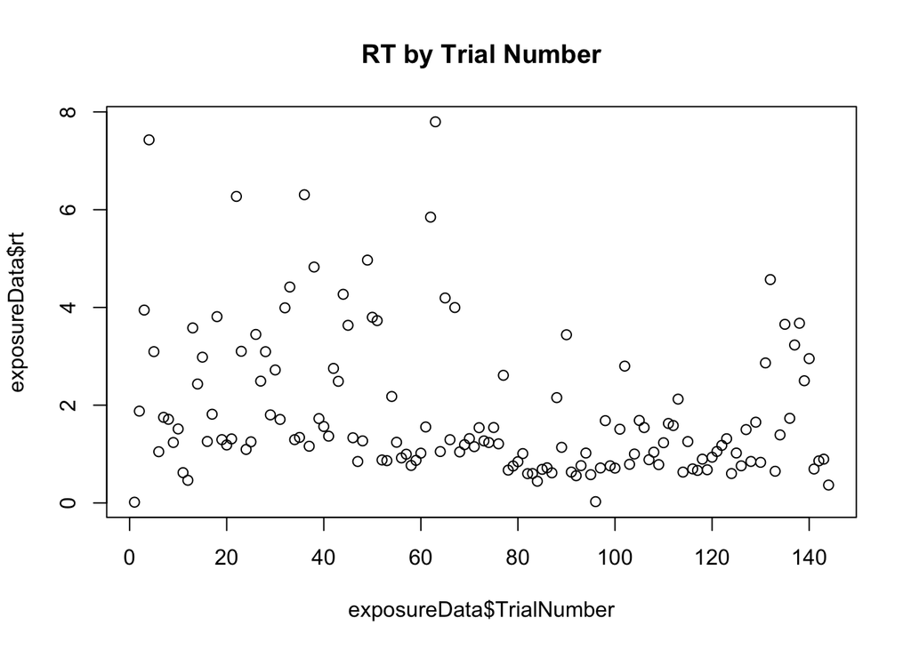

```r
plot(exposureData$TrialNumber, exposureData$rt, main= "RT by Trial Number")
```

```r
cor.test(exposureData$TrialNumber, exposureData$rt)
```

```
##
##  Pearson's product-moment correlation
##
## data:  exposureData$TrialNumber and exposureData$rt
## t = -3.4958, df = 142, p-value = 0.0006309
## alternative hypothesis: true correlation is not equal to 0
## 95 percent confidence interval:
##  -0.4254844 -0.1236169
## sample estimates:
##        cor
## -0.2815007
```

It goes down (not surprisingly)!

**Is RT longer after transition nodes?**

```r
exposureData$transition_node <- ifelse((exposureData$node1==4 & exposureData$node2 ==5) |(exposureData$node1 ==5 & exposureData$node2 ==4), 1, 0)
exposureData$transition_node <- factor(exposureData$transition_node, labels=c("No", "Yes"))
exposureData %>%  group_by(transition_node) %>% summarise(avg_rt=mean(rt), med_rt=median(rt), std_dev=sd(rt), n_trials=n())
```

| transition_node | avg_rt | med_rt | std_dev | n_trials |
| --- | --- | --- | --- | --- |
| No | 1.756525 | 1.25506 | 1.417071 | 135 |
| Yes | 3.020354 | 2.95286 | 1.581692 | 9 |

Yes!

**How long does it take with 150 nodes?**

```r
max(exposureData$onset)/60
```

```
## [1] 9.383067
```

### Sequence Completion Task

```r
table(seqcmplData$correct)
```

```
##
## Incorrect   Correct
##         1         7
```

How many are correct (within rather than between community)? 88%

### Dyadic Choice

```r
mean(dyadData$correct)
```

```
## [1] 0.5769231
```

58% correct on Dyadic Choice.

Does average number correct differ by trial type?

```r
dyadData %>% group_by(trial_type) %>% summarise(avg_correct=mean(correct))
```

| trial_type | avg_correct |
| --- | --- |
| friends_between | 1.000 |
| friends_within | 0.750 |
| non_friends_between_dist2 | 0.250 |
| non_friends_between_dist4 | 0.750 |
| non_friends_within | 0.375 |

Does the average number they say are friends (yes answers) differ by trial type?

Haven’t done this yet.

**Does RT differ by trial type?**

```r
dyadData %>% group_by(trial_type) %>% summarise(avg_rt=mean(rt), med_rt=median(rt), std_dev=sd(rt), n_trials=n())
```

| trial_type | avg_rt | med_rt | std_dev | n_trials |
| --- | --- | --- | --- | --- |
| friends_between | 1.095422 | 1.095422 | 0.2393952 | 2 |
| friends_within | 1.324281 | 1.292750 | 0.1944085 | 8 |
| non_friends_between_dist2 | 2.663960 | 2.200470 | 1.8561609 | 4 |
| non_friends_between_dist4 | 1.449442 | 1.478155 | 0.4802310 | 4 |
| non_friends_within | 2.942321 | 1.796945 | 2.5143605 | 8 |

Yes! RT is longest in non-friends within and non-friends between with a short distance.

**Does RT differ by sequence-longer later in the sequence, or shorter?**

```r
cor.test(dyadData$TrialNumber, dyadData$rt)
```

```
##
##  Pearson's product-moment correlation
##
## data:  dyadData$TrialNumber and dyadData$rt
## t = -0.24408, df = 24, p-value = 0.8092
## alternative hypothesis: true correlation is not equal to 0
## 95 percent confidence interval:
##  -0.4288473  0.3442255
## sample estimates:
##         cor
## -0.04976145
```

No it does not.

### Conclusions

88% accuracy on sequence completion and 58% accuracy on dyadic choice. Took 9 min with 150 nodes when not told to press as fast as you can. RT is longer on transition nodes (4 to 5 or 5 to 4).

## NL007

```r
exposureData <- read.delim(paste0(logdir, "NL007/NL007_log_run1.csv"))
seqcmplData <- read.csv(paste0(datadir, "NL007/seqcmpl/NL007_log_seqcmpl.csv"))
omotData<- read.csv(paste0(datadir, "NL007/OMOT/NL007_log_omot.csv"))
#dyadData <- read.csv(paste0(datadir, "NL004/dyad_choice/NL004_log_dyad_choice.csv"))
seqcmplData$correct <- factor(seqcmplData$correct, ordered=TRUE, levels=c(0,1), labels=c("Incorrect", "Correct"))
#omotData$correct <- factor(omotData$correct, ordered=TRUE, labels=c("Incorrect", "Correct")) #commented out because if make them factors then can't do proportion calculations on them.
```

### Exposure data

What does reaction time on the exposure walk look like?

```r
summary(exposureData$rt)
```

```
##     Min.  1st Qu.   Median     Mean  3rd Qu.     Max.
##  0.01744  1.34100  2.73278  3.70714  5.63383 18.73540
```

**Does RT go down or up as the task goes on?**

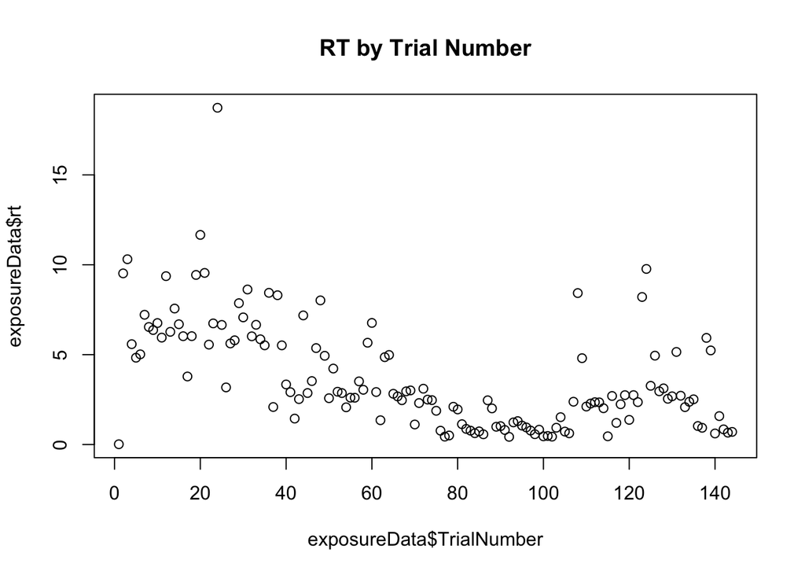

```r
plot(exposureData$TrialNumber, exposureData$rt, main= "RT by Trial Number")
```

```r
cor.test(exposureData$TrialNumber, exposureData$rt)
```

```
##
##  Pearson's product-moment correlation
##
## data:  exposureData$TrialNumber and exposureData$rt
## t = -7.9066, df = 142, p-value = 6.711e-13
## alternative hypothesis: true correlation is not equal to 0
## 95 percent confidence interval:
##  -0.6570338 -0.4280107
## sample estimates:
##        cor
## -0.5528784
```

It goes down (not surprisingly)!

**Is RT longer after transition nodes?**

```r
exposureData$transition_node <- ifelse((exposureData$node1==4 & exposureData$node2 ==5) |(exposureData$node1 ==5 & exposureData$node2 ==4), 1, 0)
exposureData$transition_node <- factor(exposureData$transition_node, labels=c("No", "Yes"))
exposureData %>%  group_by(transition_node) %>% summarise(avg_rt=mean(rt), med_rt=median(rt), std_dev=sd(rt), n_trials=n())
```

| transition_node | avg_rt | med_rt | std_dev | n_trials |
| --- | --- | --- | --- | --- |
| No | 3.718136 | 2.74944 | 3.003978 | 135 |
| Yes | 3.542263 | 2.71613 | 2.399528 | 9 |

Not really.

**How long does it take with 150 nodes?**

```r
max(exposureData$onset)/60
```

```
## [1] 13.66973
```

### Sequence Completion Task

```r
table(seqcmplData$correct)
```

```
##
## Incorrect   Correct
##         3         5
```

How many are correct (within rather than between community)? 62%

### Odd Man Out Task

```r
summary(omotData$correct)
```

```
##    Min. 1st Qu.  Median    Mean 3rd Qu.    Max.
##    0.00    0.75    1.00    0.75    1.00    1.00
```

On average, 75% correct on OMOT.

Does average number correct differ by trial type?

```r
omotData %>% group_by(trial_type) %>% summarise(avg_correct=mean(correct))
```

| trial_type | avg_correct |
| --- | --- |
| catch | 0.8333333 |
| conservative | 1.0000000 |
| non_conservative | 0.4444444 |

The ‘correct’ answer for catch trials is the node that is 2 edges away rather than one edge away. 44% is still above chance on the non-conservative trials!

**Does RT differ by trial type?**

```r
omotData %>% group_by(trial_type) %>% summarise(avg_rt=mean(rt), med_rt=median(rt), std_dev=sd(rt), n_trials=n())
```

| trial_type | avg_rt | med_rt | std_dev | n_trials |
| --- | --- | --- | --- | --- |
| catch | 3.384037 | 2.559695 | 1.971684 | 12 |
| conservative | 3.402542 | 2.452025 | 2.161286 | 18 |
| non_conservative | 3.616796 | 2.997350 | 2.174267 | 18 |

**Does RT differ by sequence-longer later in the sequence, or shorter?**

```r
cor.test(omotData$TrialNumber, omotData$rt)
```

```
##
##  Pearson's product-moment correlation
##
## data:  omotData$TrialNumber and omotData$rt
## t = -1.7566, df = 46, p-value = 0.08565
## alternative hypothesis: true correlation is not equal to 0
## 95 percent confidence interval:
##  -0.49928664  0.03597737
## sample estimates:
##        cor
## -0.2507203
```

Not significantly, but gets slightly faster.

## NL008

NL008 only finished the sequence completion task, did not do dyadic choice or OMOT due to an error in the code. Here, we changed the protocol to be better for kids such that participants had to tap on the monsters, which then made a sound, and do it as fast as they can.

```r
exposureData <- read.delim(paste0(logdir, "NL008/NL008_log_run1.csv"))
seqcmplData <- read.csv(paste0(datadir, "NL008/seqcmpl/NL008_log_seqcmpl.csv"))
seqcmplData$correct <- factor(seqcmplData$correct, ordered=TRUE, levels=c(0,1), labels=c("Incorrect", "Correct"))
```

### Exposure data

What does reaction time on the exposure walk look like?

```r
summary(exposureData$rt)
```

```
##    Min. 1st Qu.  Median    Mean 3rd Qu.    Max.
## 0.02055 0.57345 0.75566 1.06983 1.06822 8.74619
```

**Does RT go down or up as the task goes on?**

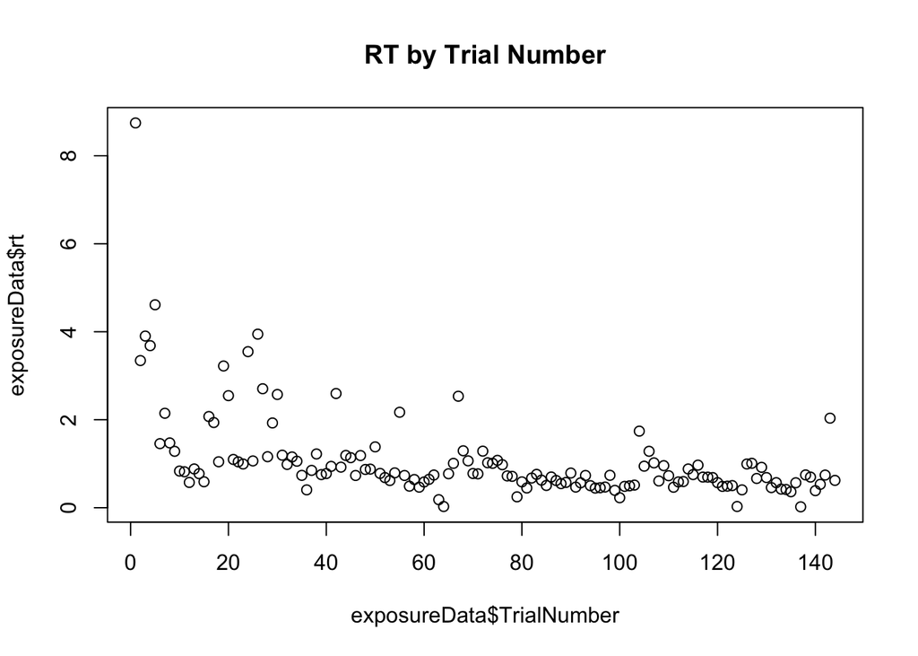

```r
plot(exposureData$TrialNumber, exposureData$rt, main= "RT by Trial Number")
```

```r
cor.test(exposureData$TrialNumber, exposureData$rt)
```

```
##
##  Pearson's product-moment correlation
##
## data:  exposureData$TrialNumber and exposureData$rt
## t = -6.8037, df = 142, p-value = 2.634e-10
## alternative hypothesis: true correlation is not equal to 0
## 95 percent confidence interval:
##  -0.6099335 -0.3615762
## sample estimates:
##        cor
## -0.4958264
```

It goes down a lot!

**Is RT longer after transition nodes?**

```r
exposureData$transition_node <- ifelse((exposureData$node1==4 & exposureData$node2 ==5) |(exposureData$node1 ==5 & exposureData$node2 ==4), 1, 0)
exposureData$transition_node <- factor(exposureData$transition_node, labels=c("No", "Yes"))
exposureData %>%  group_by(transition_node) %>% summarise(avg_rt=mean(rt), med_rt=median(rt), std_dev=sd(rt), n_trials=n())
```

| transition_node | avg_rt | med_rt | std_dev | n_trials |
| --- | --- | --- | --- | --- |
| No | 1.059822 | 0.758210 | 1.028317 | 139 |
| Yes | 1.348080 | 0.618694 | 1.211883 | 5 |

Average is, but not really.

**How long does it take with 150 nodes?**

```r
max(exposureData$onset)/60
```

```
## [1] 7.54015
```

```r
table(seqcmplData$correct)
```

```
##
## Incorrect   Correct
##         2         6
```

How many are correct (within rather than between community)? 75%